```r
setwd('/home/lien/data/skrypty/TFIIB/')
library("tidyverse")
source('functions.R')
```

#### provide the path to GMatrix.RDS files

```r
data_dir='/home/lien/data/TFIIB/GEO_upload/HiC/'
```

### load the metadata for Hi-C samples

```r
sample_info <- read_tsv('/home/lien/data/skrypty/TFIIB/samples_GEO_HiC.tsv',col_types='ffffff')
sample_info
```

```
## # A tibble: 12 × 6
##    sample   genotype condition brep  stress  plants
##    <fct>    <fct>    <fct>     <fct> <fct>   <fct>
##  1 Sample1  Wt       NT        r1    water   naive
##  2 Sample2  Wt       S1        r1    drought naive
##  3 Sample3  Wt       R         r1    water   trained
##  4 Sample4  Wt       S2        r1    drought trained
##  5 Sample5  R58C     NT        r1    water   naive
##  6 Sample6  R58C     S1        r1    drought naive
##  7 Sample7  R58C     R         r1    water   trained
##  8 Sample8  R58C     S2        r1    drought trained
##  9 Sample9  Wt       NT        r2    water   naive
## 10 Sample10 Wt       S1        r2    drought naive
## 11 Sample11 Wt       R         r2    water   trained
## 12 Sample12 R58C     S1        r2    drought naive
```

### analyse all samples

```r
samples=c(1:12)
```

### prepare the lists of genes: from 3 to 50kb, present in any of groups from PCSD database that are enriched in the gene-body region is histone acetylation: chromatin states S22 to S28 (see functions.R for details). The group ‘rest’ will also be generated from all other protein coding genes

```r
group_sets=list('geneBody'='acetylated')
down_thresh=3000
up_thresh=50000
Groups <- create_Groups(group_sets,down_thresh,up_thresh,complement_rest=T,exclusive=F)
```

### Create a unique directory to save matrix files and reports

```r
barcode=paste0(paste0(sample(c(letters,LETTERS),5,replace=T),collapse=""),as.integer(as.POSIXct(Sys.time())))
output_path = paste0(barcode,'/')
system(paste0('mkdir ',output_path),intern=F)
```

### Calculate meta-gene matrizes for specified groups and samples. Immediately save the results as symmetric matrices.

### Both raw and distance-normalized matrixes are generated. This may take some time

```r
system.time({
metamatrix_data <- lapply(1:length(Groups),function(G){
  lapply(samples,function(s){
    genes=Groups[[G]]
    result <- calculate_metamatrix(genes,s)
    result$sample=paste0('Sample',s)
    result$name <- unite(sample_info,c(2:4),col='name',sep='_' )[which(sample_info$sample==result$sample),] %>% pull(name)
    result$group=names(Groups)[G]
    title=paste0(result$sample,'_',result$group,'_',down_thresh/1000,' kb to ',up_thresh/1000,' kb.matrix')
    write.table(result$mat_raw, file=paste0(output_path,'Meta_raw_',title), sep='\t', row.names = F, col.names =  F)
    write.table(result$mat_norm, file=paste0(output_path,'Meta_norm_',title), sep='\t', row.names = F, col.names =  F)
    return(result)
  })
}) %>% reduce(c)
})
```

```
##     user   system  elapsed
## 4783.847    2.017 4800.366
```

### Plot the first gene group from the first sample

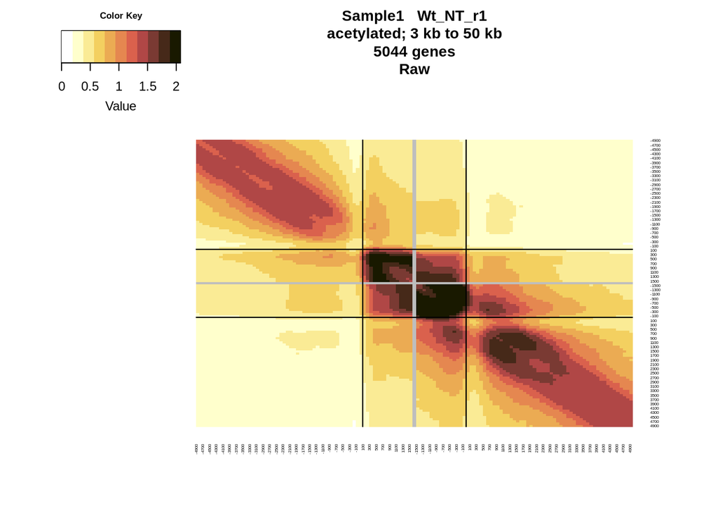

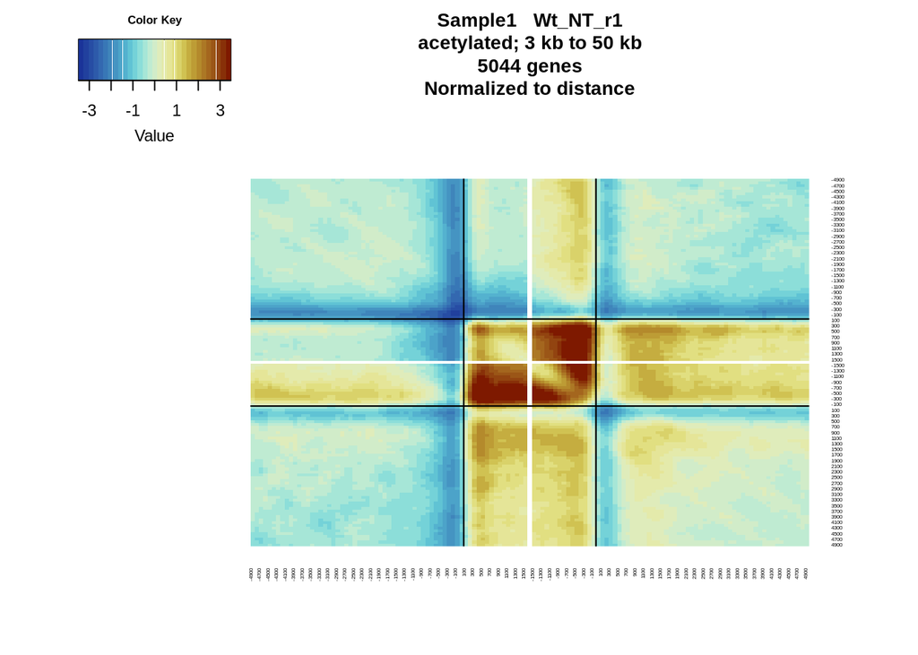

```r
x=metamatrix_data[[1]]
title=paste0(x$sample,'   ',x$name,'\n',x$group,'; ',down_thresh/1000,' kb to ',up_thresh/1000,' kb\n',x$nr_of_genes,' genes')
f_draw_matrix(raw_array=x$mat_raw, norm_array=x$mat_norm,title=title,threshold=0.99)
```

### set the common scale for heatmaps

```r
threshold=0.99
max_norm = quantile(abs(scale(unlist(lapply(metamatrix_data,function(x){x$'mat_norm'})))),probs=threshold,na.rm=T)
```

### create a pdf report with all heatmaps

```r
 pdf_file=paste0(output_path,paste0(unlist(group_sets),collapse='_'),'.pdf')
 pdf(pdf_file)
lapply(metamatrix_data, function(x){
  title=paste0(x$sample,'   ',x$name,'\n',x$group,'; ',down_thresh/1000,' kb to ',up_thresh/1000,' kb\n',x$nr_of_genes,' genes')
     f_draw_matrix(raw_array=x$mat_raw, norm_array=x$mat_norm,title=title,threshold=threshold,max_scale_norm=max_norm)
})
```

```r
dev.off()
```

## the heatmaps on Fig. 4C are from combined samples from water/drought conditions

## matrixes for each group of genes and for each sample can be loaded directly. Change the path to the dir containing matrix samples saved in the previous step, if necessary

#output_path=’’

```r
#output_path=''
Samples=list(WT=list(water=c(1,3,9,11),drought=c(2,4,10)),R58C=list(water=c(5,7),drought=c(6,8,12)))
matrices <- lapply(names(Groups),function(group){
  # group=names(Groups)[3]
   lapply(Samples,function(genotype){
    lapply(genotype,function(condition){
      lapply(condition,function(sample){
        norm_matrix <- read_tsv(paste0(output_path,'Meta_norm_Sample',sample,'_',group,'_',down_thresh/1000,' kb to ',up_thresh/1000,' kb.matrix'), col_names=F) %>%
          as.matrix()
         scaled_norm_matrix <- (norm_matrix-mean(norm_matrix,na.rm=T))/sd(norm_matrix,na.rm=T)
      }) %>% Reduce('+',.)/length(condition)
    })
  })
})
names(matrices)<-names(Groups)
```

```r
conditions=c('drought','water')
deltas <- lapply(names(Groups),function(group){lapply(conditions,function(condition){
 d_array = matrices[[group]][['R58C']][[condition]]-matrices[[group]][['WT']][[condition]]
 title=paste0(group,'\n',condition,'\nR58C-WT\nDifferential matrix')
 return(list(delta_array=d_array, group=group, condition=condition))
 })})%>% reduce(c)
```

### set the common scale for heatmaps

```r
threshold=0.9999
max_norm = quantile(abs((unlist(matrices))),probs=threshold,na.rm=T)
max_delta = quantile(abs((unlist(lapply(deltas,function(x){x$delta_array})))),probs=threshold,na.rm=T)
```

### plot the heatmaps

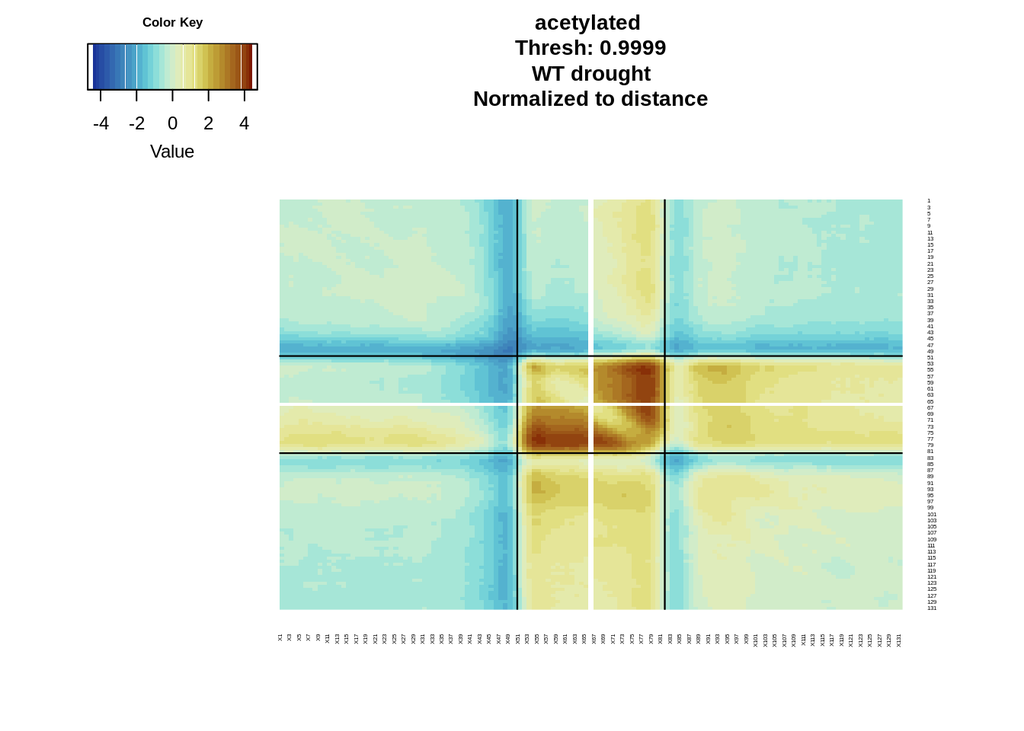

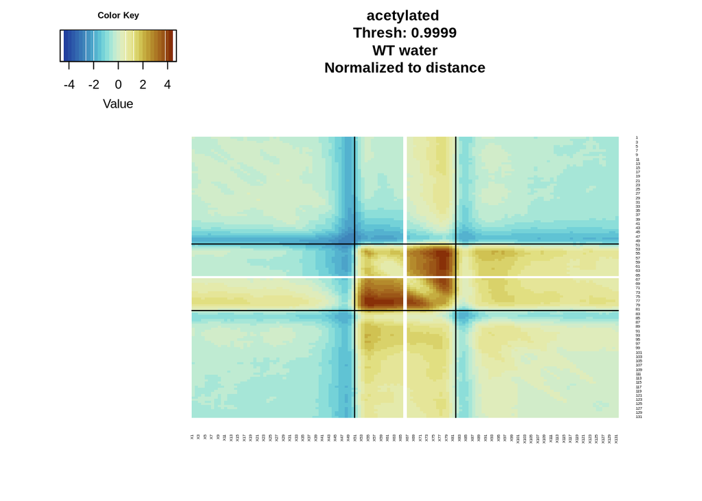

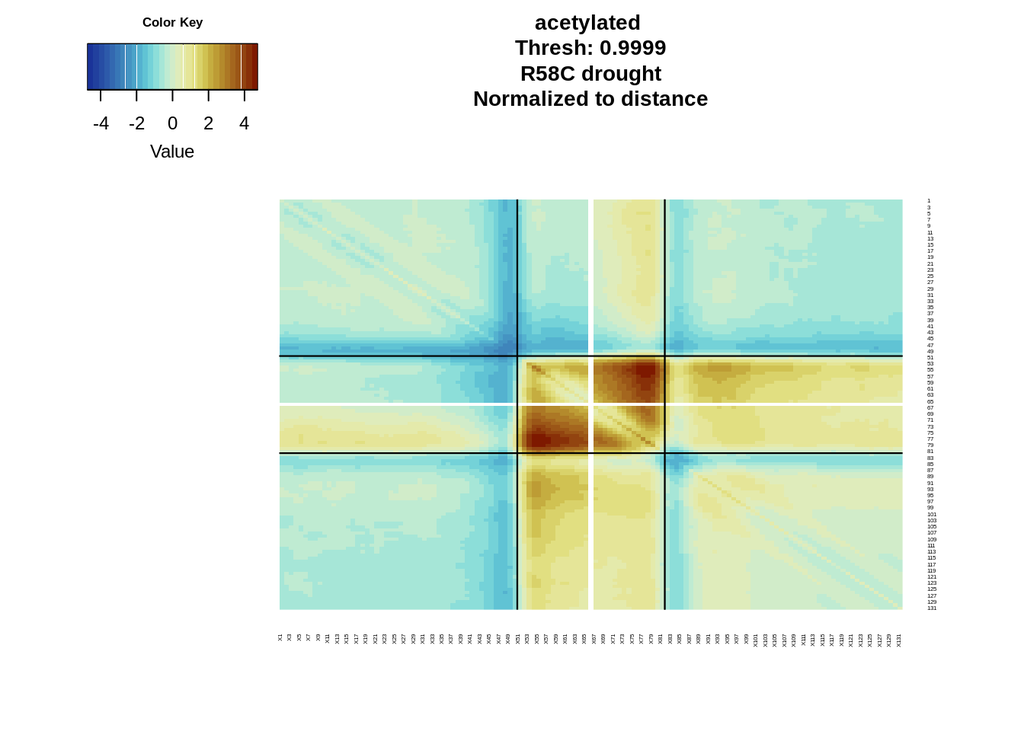

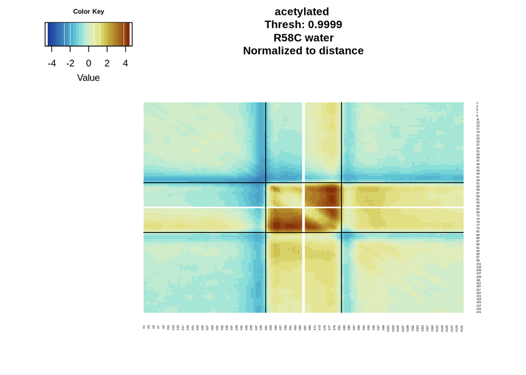

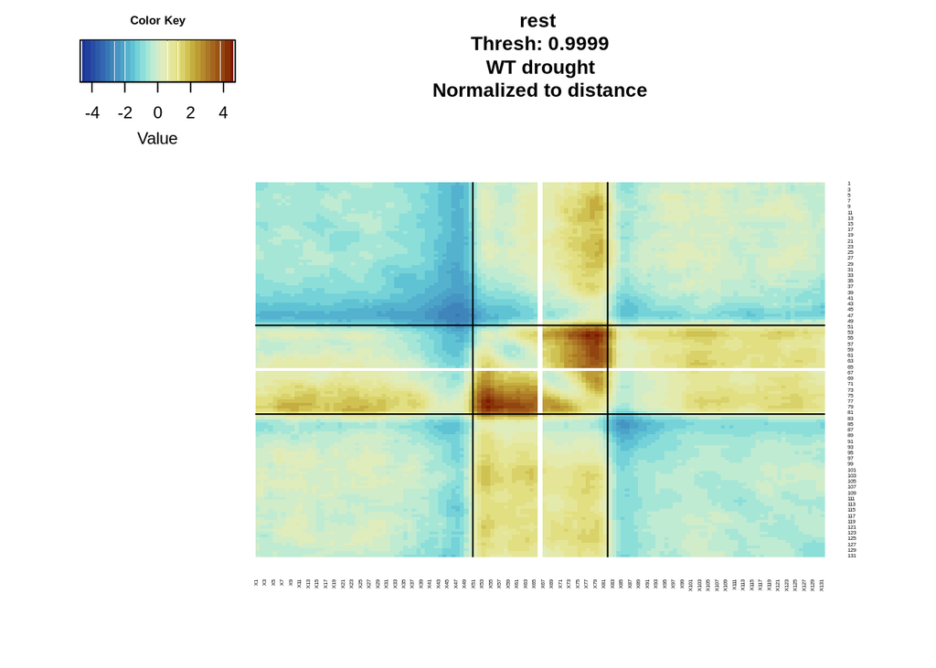

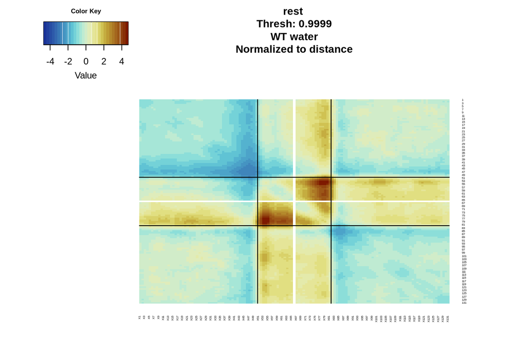

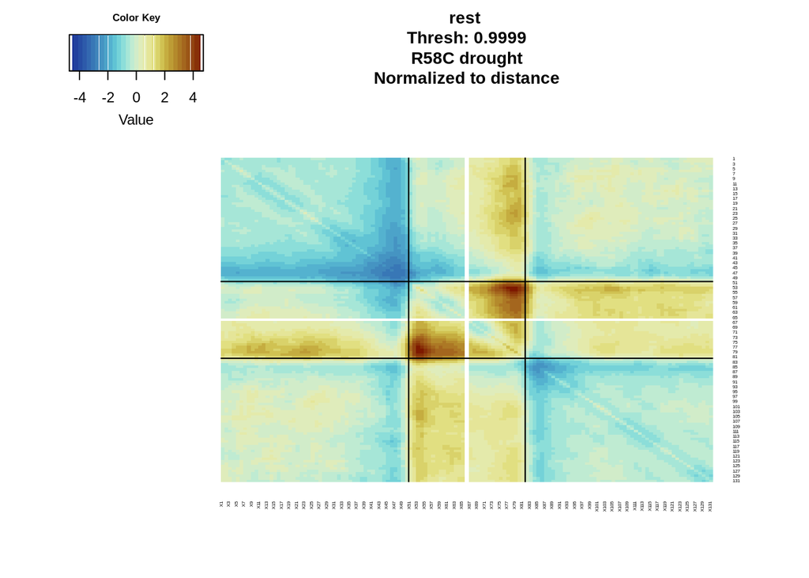

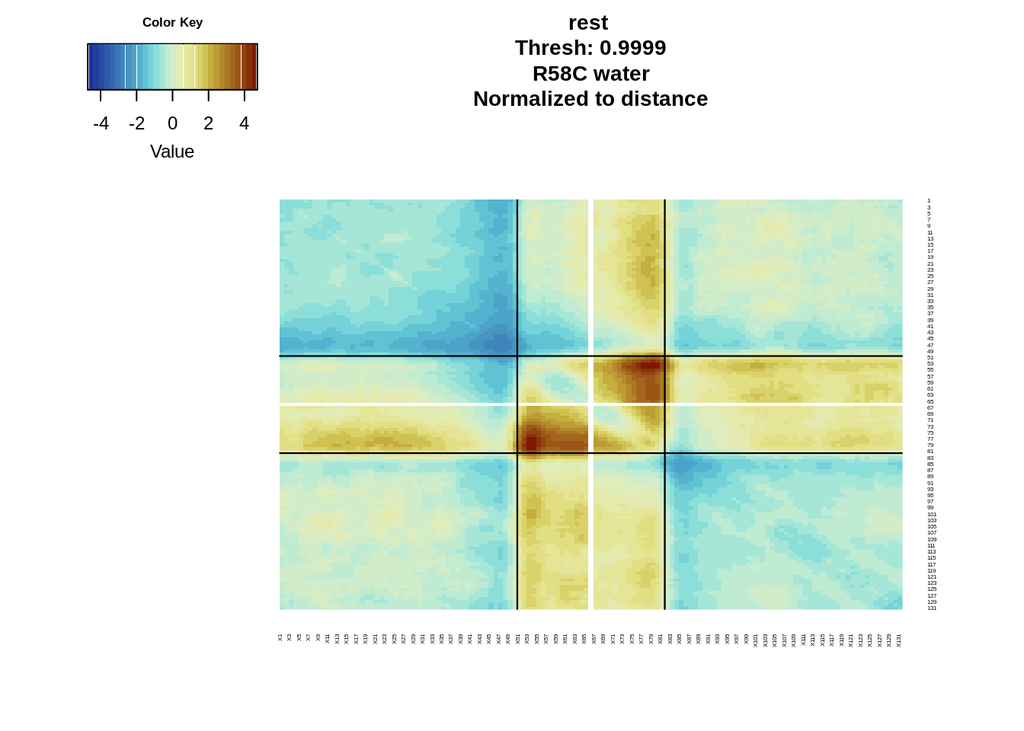

```
## [[1]]
## [[1]][[1]]
## [[1]][[1]][[1]]
## NULL
##
## [[1]][[1]][[2]]
## NULL
##
##
## [[1]][[2]]
## [[1]][[2]][[1]]
## NULL
##
## [[1]][[2]][[2]]
## NULL
##
##
##
## [[2]]
## [[2]][[1]]
## [[2]][[1]][[1]]
## NULL
##
## [[2]][[1]][[2]]
## NULL
##
##
## [[2]][[2]]
## [[2]][[2]][[1]]
## NULL
##
## [[2]][[2]][[2]]
## NULL
```

```r
lapply(names(Groups),function(group){
lapply(names(Samples),function(genotype){
  lapply(conditions,function(condition){
    norm_map <- matrices[[group]][[genotype]][[condition]]
    title=paste0(group,' \nThresh: ',threshold,'\n',genotype,' ',condition)

    f_draw_matrix(norm_array=norm_map, title=title, do_scaling=F,max_scale_norm=max_norm)
  })
})
})
```

### make a pdf report

```r
  pdf_file=paste0(output_path,paste0(names(Groups),collapse='_'),'.pdf')
  pdf(pdf_file)
lapply(names(Groups),function(group){
lapply(names(Samples),function(genotype){
  lapply(conditions,function(condition){
    norm_map <- matrices[[group]][[genotype]][[condition]]
    title=paste0(group,' \nThresh: ',threshold,'\n',genotype,' ',condition)

    f_draw_matrix(norm_array=norm_map, title=title, do_scaling=F,max_scale_norm=max_norm)
  })
})
})
```

```
## [[1]]
## [[1]][[1]]
## [[1]][[1]][[1]]
## NULL
##
## [[1]][[1]][[2]]
## NULL
##
##
## [[1]][[2]]
## [[1]][[2]][[1]]
## NULL
##
## [[1]][[2]][[2]]
## NULL
##
##
##
## [[2]]
## [[2]][[1]]
## [[2]][[1]][[1]]
## NULL
##
## [[2]][[1]][[2]]
## NULL
##
##
## [[2]][[2]]
## [[2]][[2]][[1]]
## NULL
##
## [[2]][[2]][[2]]
## NULL
```

```r
lapply(deltas, function(d){
  title=paste0(d$group,'\n',d$condition,'\nR58C-WT')

  f_draw_matrix(delta_array=d$delta_array, title=title, do_scaling=F, max_scale_delta=max_delta)
})
```

```r
  dev.off()
```

### Fig. 4C, lower panels - mean asymmetry ratios in each sample

### Pull the data from *sectors.tsv files

```r
sector_data <- lapply(1:12,function(i){
  read_tsv(paste0('/home/lien/data/TFIIB/GEO_upload/HiC/Sample',i,'_sectors.tsv'), col_types='cdddc')
}) %>% reduce(bind_rows)
```

```r
group_sets=list('geneBody'='acetylated','other'='All_PCG')
down_thresh=3000
up_thresh=50000
Groups <- create_Groups(group_sets,down_thresh,up_thresh,complement_rest=T,exclusive=F)
```

### calculate mean asymmetry ratio for each group of genes, for each sample

```r
summary <- make_contact_summary(data=sector_data,Groups)
```

### create plots

```r
plots <- report_contact_summary(summary,Groups)
```

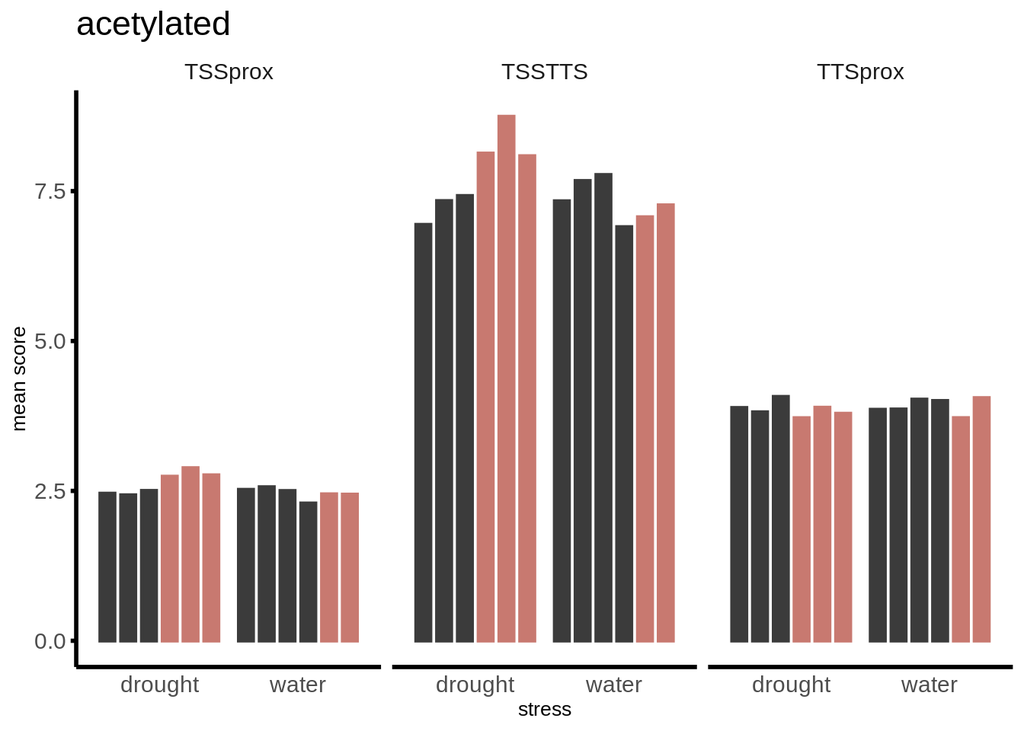

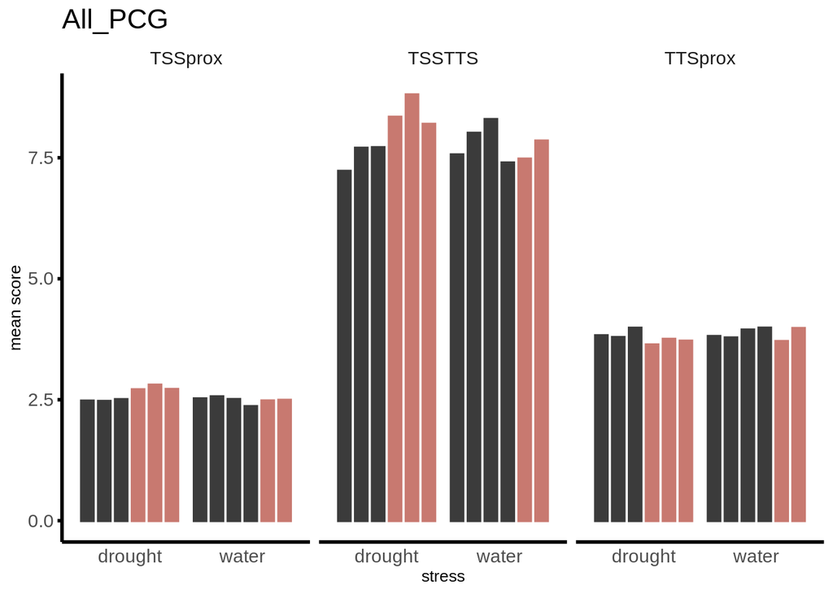

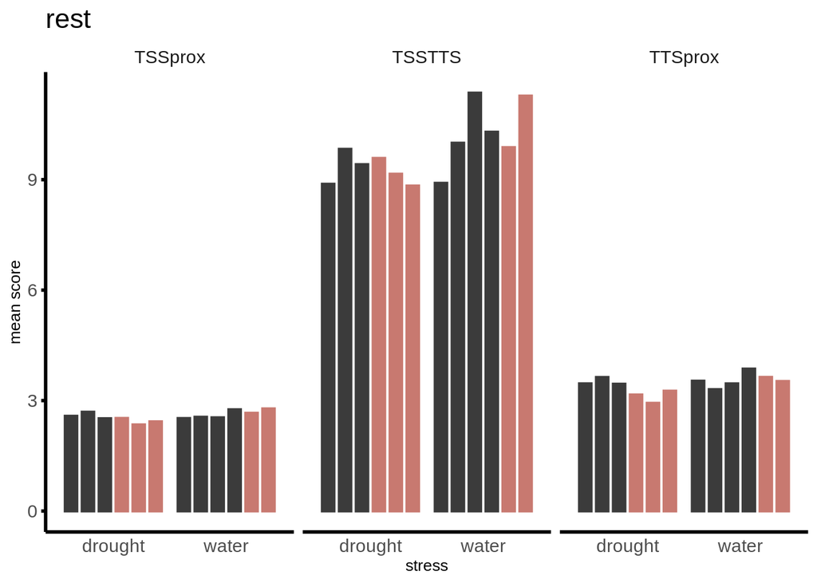

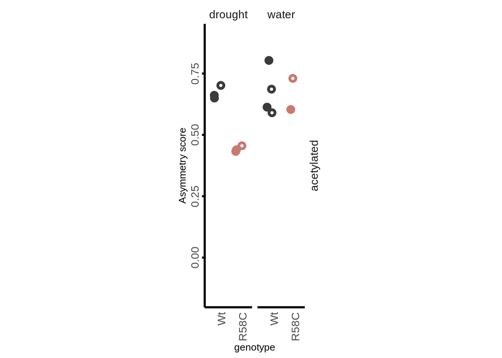

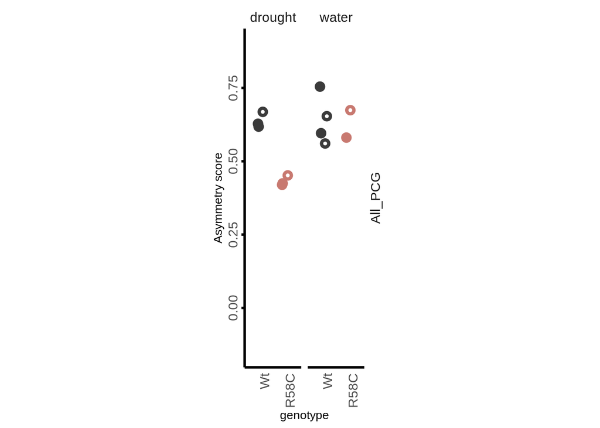

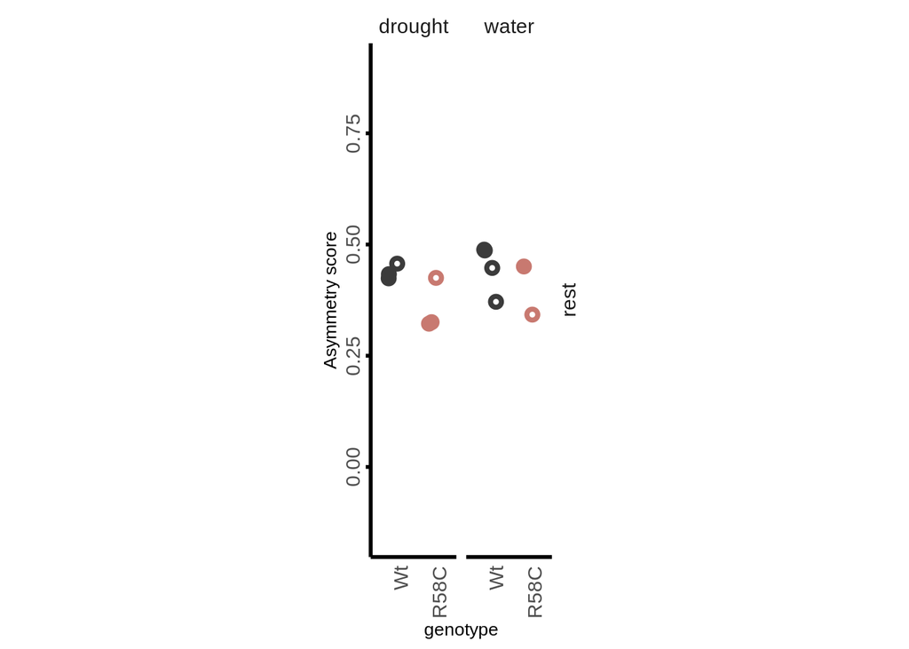

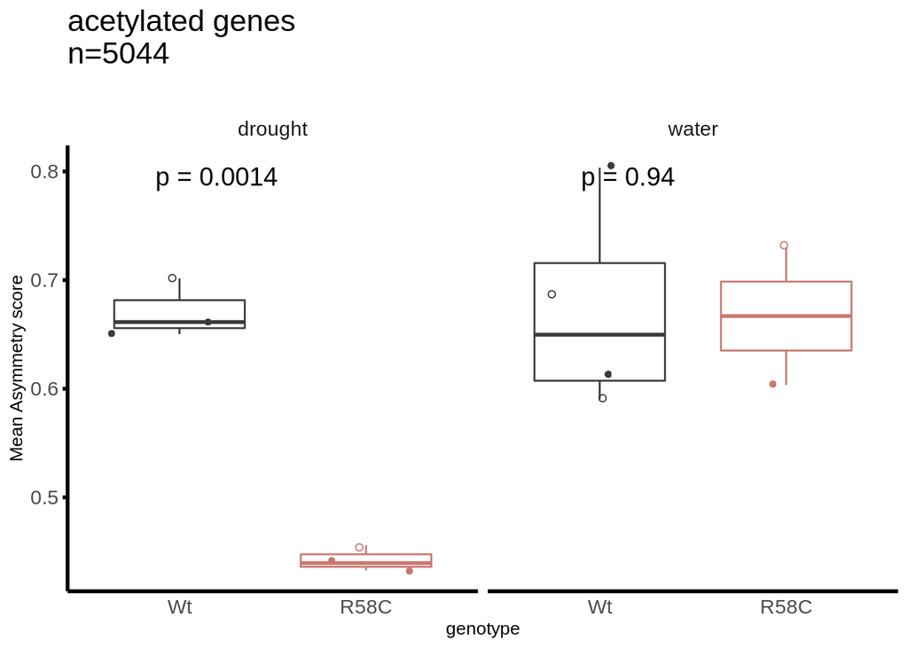

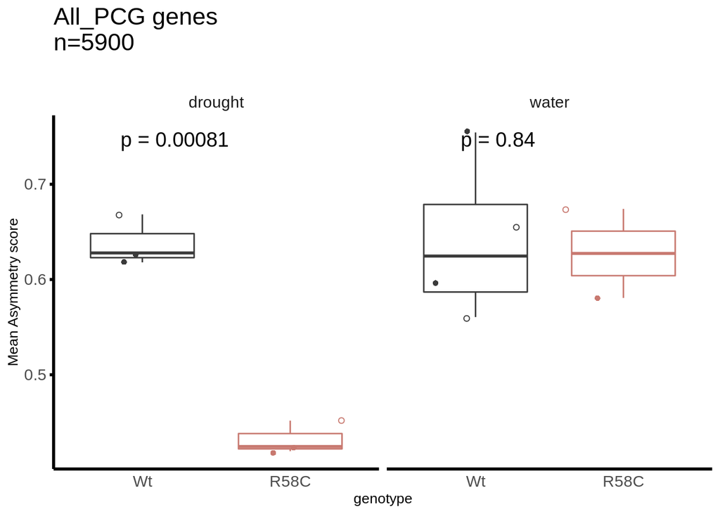

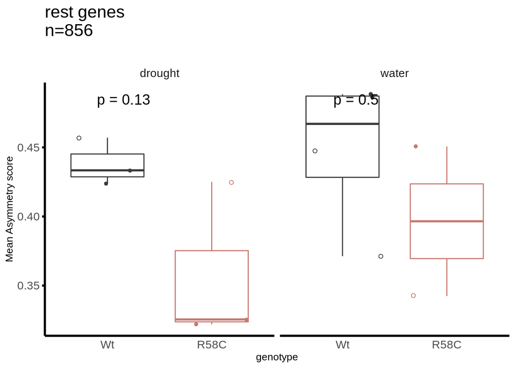

```
##
## $boot_plot
## $boot_plot[[1]]
```

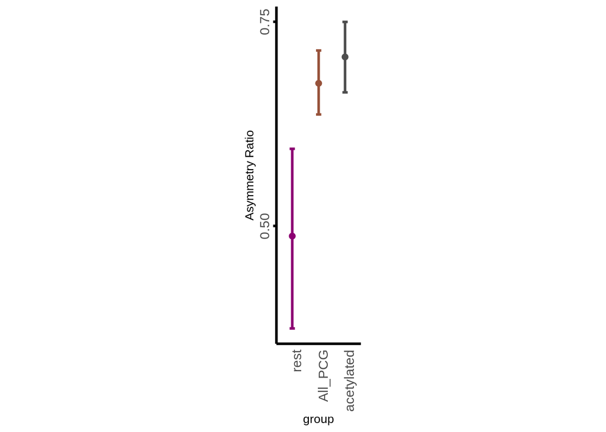

[output not shown]

[output cut: 29 more lines]

```r
plots$boot_plot <- bootANDplot(data=sector_data,Groups,merge_samples=c(1,9))

lapply(plots,function(x){x})
```

### make a pdf report with all plots and table-summary

```r
pdf_name=paste0(output_path, 'AsymRatio_Fig4AB.pdf')
pdf(pdf_name,width = 4, height = 4)
print(plots)
```

```
##
## $boot_plot
## $boot_plot[[1]]
```

[output not shown]

[output cut: 29 more lines]

```r
lapply(names(Groups),function(x){
  table <- summary %>% select(group, sample,mean_AsRatio) %>%
    subset(group==x)%>%
    tableGrob(theme=ttheme_default(base_size=6))
   grid.newpage()
  grid.draw(table)
})
```

```r
dev.off()
```

```r
### plots can be saved as .svg
# lapply(1:length(plots),function(x){
#   svg(paste0(output_path,x,'.svg'),width = 4, height = 4)
#   print(plots[[x]])
#   dev.off()
# })
```